#### Oil & Gas

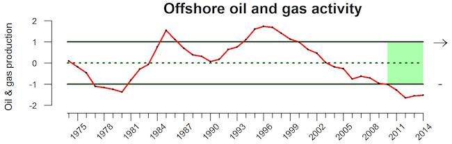

**Figure App.C.4.17.**. A figure showing trends in offshore oil and gas activity in Southern California from 1975 - 2014.

**Click for Details**

The status and trends of offshore oil and gas activity in southern California was measured using a normalized index of oil and gas production from offshore wells in state and federal waters in California. Activity has been stable over the last five years, but the short-term average was well below the long-term average (dashed green line). A rather steady decrease in oil and gas production has occurred since the mid-1990s. Data source: Annual reports of the California State Department of Conservation’s Division of Oil, Gas, and Geothermal Resources; Figure: K. Andrews/NOAA

##### Oil & Gas Maps

###### Offshore Oil Platforms

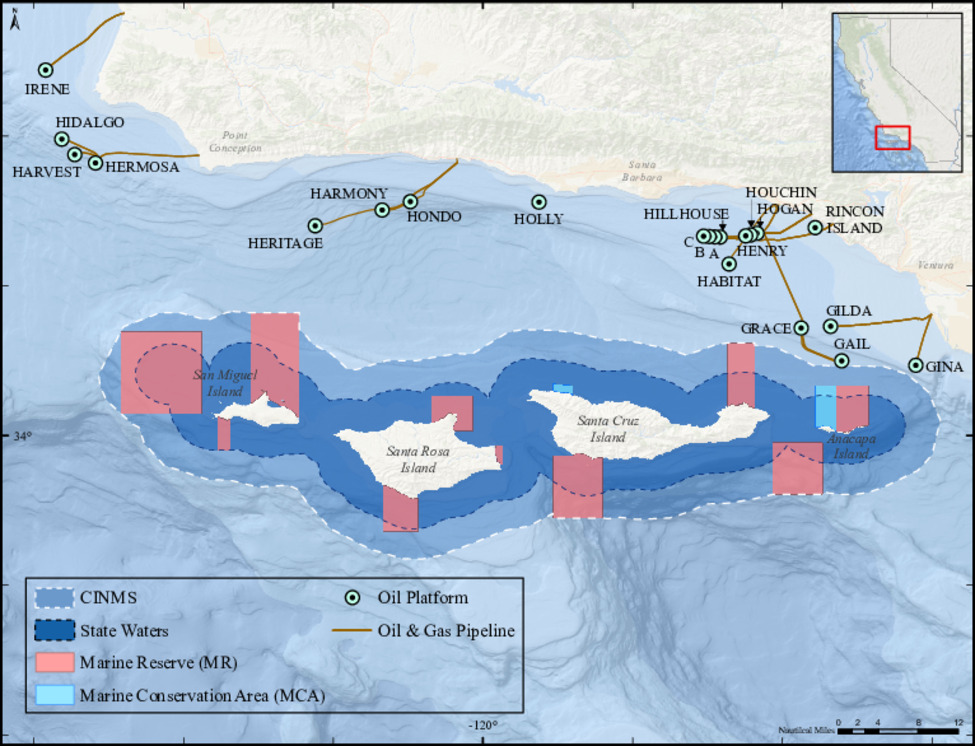

**Click for Details**

Data source: [State of California GeoPortal](https://gis.data.ca.gov/); Map: [M. Cajandig/NOAA](https://channelislands.noaa.gov/contact/cajandig.html)

###### 2015 Refugio Oil Spill

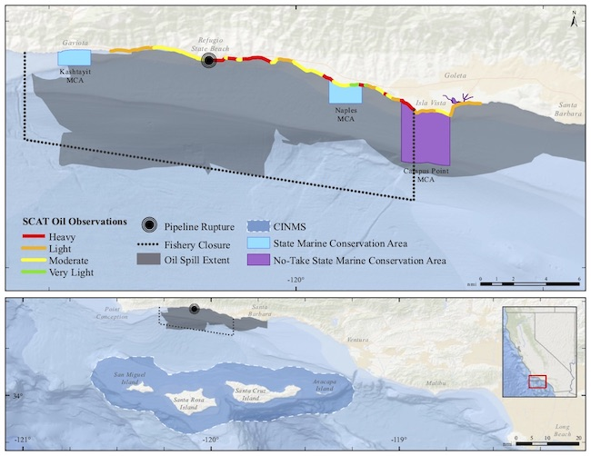

**Figure App.C.2.3.**. A map showing the area around the Santa Barbara Coast affected by the 2015 Refugio Oil Spill.

**Click for Details**

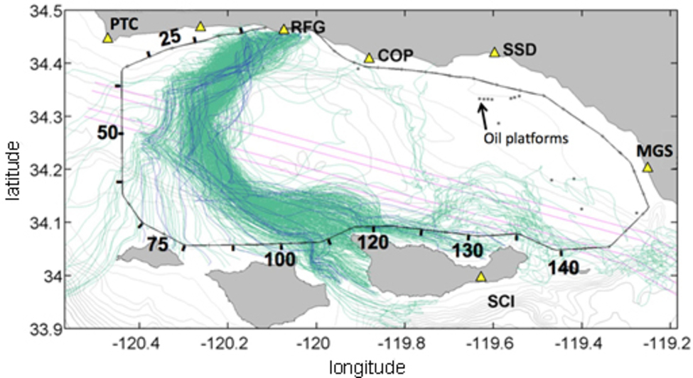

**Figure App.C.2.4.**. A map showing projected oil movement following the Refugio Oil Spill in May 2015.

**Click for Details**

Modeled oil trajectories based on high frequency (HF) radar and averaged sea surface current vectors during the month of May 2015 (green and blue lines). Yellow triangles represent SCCOOS HF Radar stations, and oil platforms are shown as small gray dots. The HF station at Gaviota was installed immediately after the spill to avoid local data gaps during this critical monitoring time period. It was only active for one and a half months. PTC = Point Conception; RFG = Refugio State Beach; COP = Coal Oil Point; SSD = Summerland Sanitary District; MGS = Mandalay Generating Station; SCI = Santa Cruz Island. Pink lines indicate commercial shipping lanes. The black line encircles the region of interest. Figure: B. Emery and [L. Washburn/UCSB](https://msi.ucsb.edu/people/faculty/libe-washburn)

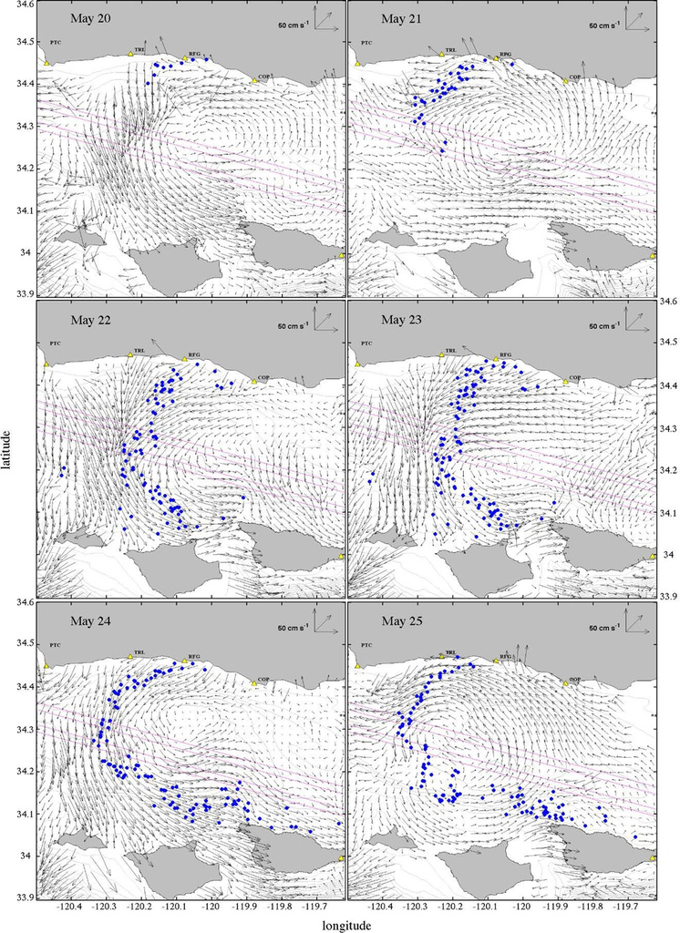

**Figure App.C.2.5.**. An image of modeled sea surface current directions used to predict oil movement from May 20 to May 25, immediately following the Refugio Oil Spill (2015).

**Click for Details**

Daily snapshots of oil transport simulations (blue dots) based on near-real time sea surface current direction and speeds (black arrows) from May 20 to 25, 2015, the days just after the Refugio oil spill. Yellow triangles represent SCCOOS high frequency radar (HFR) observation stations. PTC = Point Conception; RFG = Refugio State Beach; COP = Coal Oil Point. Not pictured is a HFR station at Gaviota, which was temporarily installed for one and half months following the spill (currently no longer active, see http://washburnlab.msi.ucsb.edu/mtu1) to address local data gaps. Not labeled is the yellow triangle/HFR station on Santa Cruz Island. Pink lines indicated commercial shipping lanes. [The full oil transport model simulation can be viewed online](http://sccoos.org/about/news/2015-refugio-state-beach-oil-spill/). Source: [SCCOOS](http://sccoos.org/); Figure: B. Emery and [L. Washburn/UCSB](https://msi.ucsb.edu/people/faculty/libe-washburn)